# Assignment 13: Text Mining

*How to do it?*:

- Open the Rmarkdown file of this assignment (link) in Rstudio.
- Right under each **question**, insert a code chunk (you can use the hotkey `Ctrl + Alt + I` to add a code chunk) and code the solution for the question.
- `Knit` the rmarkdown file (hotkey: `Ctrl + Alt + K`) to export an html.
- Publish the html file to your Githiub Page.

*Submission*: Submit the link on Github of the assignment to Canvas

Sample Codes

### Netflix Data

**1.** Download the `netflix_titles` at this link. Create a century variable taking two values:

```
- '21' if the released_year is greater or equal to 2000, and

- '20' otherwise.
```

```r
library(tidyverse)
library(dplyr)
df <- read_csv('netflix_titles (11).csv')
```

```r
df$century <- case_when(df$release_year>=2000 ~ '21', df$release_year<=1999 ~ '20')
```

**2. Word Frequency**

1. Convert the description to tokens, remove all the stop words. What are the top 10 frequent words of movies/TV Shows in the 20th century. Plot the bar chart of the frequency of these words.

```r
library(tidyverse)
library(tidytext)
library(knitr)
```

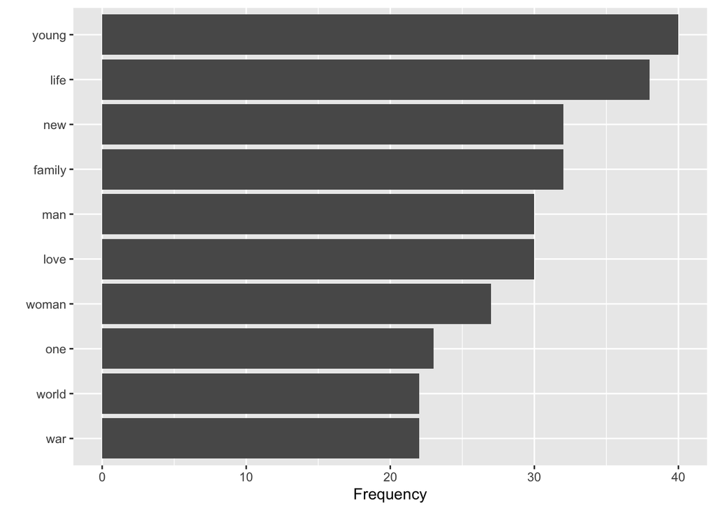

```r
df %>%
  unnest_tokens(input = description, output = word) %>%
  anti_join(get_stopwords()) %>%
  count(century, word, sort = TRUE) %>%
  filter(century=='20') %>%
  head(10) %>%
  ggplot(aes(x = n, y = reorder(word, n))) +
  geom_col() +
  labs(y = '', x = 'Frequency')
```

2. What are the top 10 frequent words of movies/TV Shows in the 21st century. Plot the bar chart of the frequency of these words. Plot a side-by-side bar charts to compare the most frequent words by the two centuries.

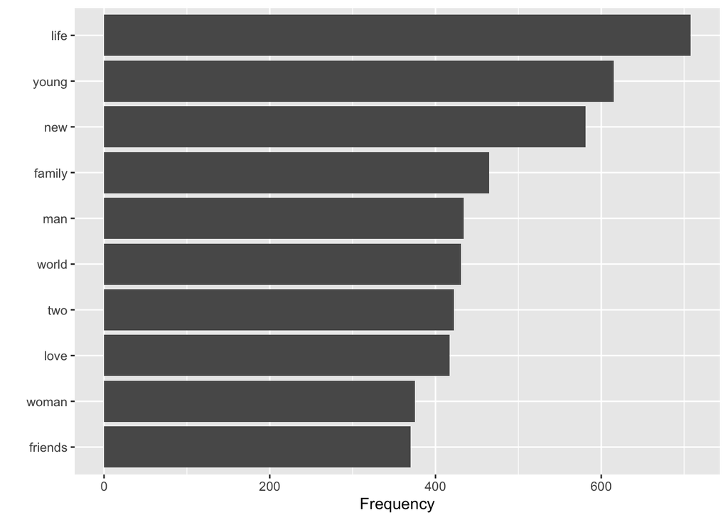

```r
df %>%
  unnest_tokens(input = description, output = word) %>%
  anti_join(get_stopwords()) %>%
  count(century, word, sort = TRUE) %>%
  filter(century=='21') %>%
  head(10) %>%
  ggplot(aes(x = n, y = reorder(word, n))) +
  geom_col() +
  labs(y = '', x = 'Frequency')
```

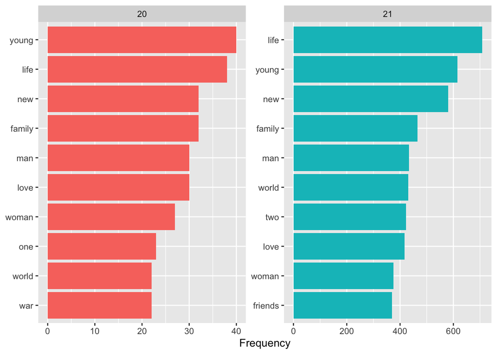

```r
df %>%
  unnest_tokens(input = description, output = word) %>%
  anti_join(get_stopwords()) %>%
  count(century, word, sort = TRUE) %>%
  group_by(century) %>%
  slice_max(n, n = 10) %>%
  ungroup() %>%
  mutate(word = reorder_within(word, by = n, within = century)) %>%
  ggplot(aes(n, word, fill = century)) +
  geom_col(show.legend = FALSE) +
  facet_wrap(~century, scales = "free") +
  labs(x = "Frequency",
       y = NULL)+
  scale_y_reordered()
```

**3. Word Cloud**

1. Plot the word cloud of the words in the descriptions in the movies/TV Shows in the 20th century.

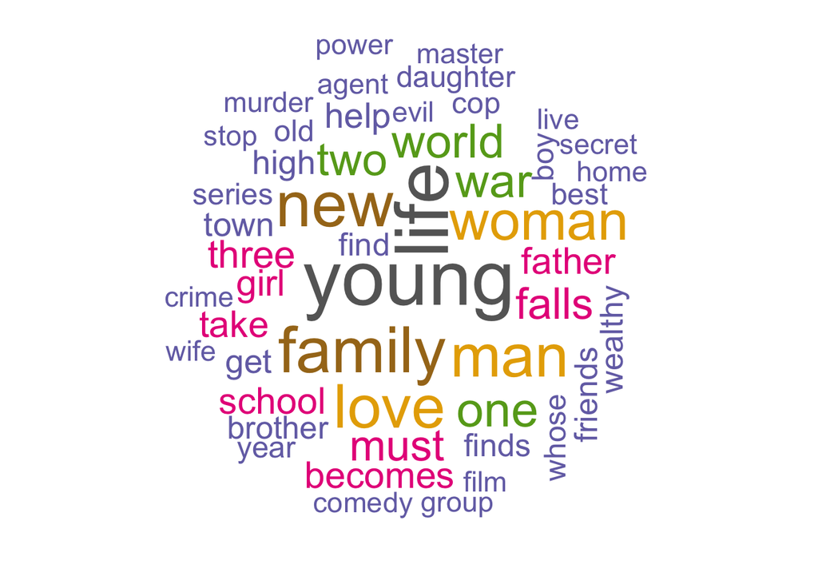

```r
library(wordcloud)
pal <- brewer.pal(8,"Dark2")

df %>%
  filter(century=='20') %>%
  unnest_tokens(input = description, output = word) %>%
  anti_join(get_stopwords()) %>%
  count(century, word, sort = TRUE) %>%
  with(wordcloud(word, n, random.order = FALSE, max.words = 50, colors=pal))
```

2. Plot the word cloud of the words in the descriptions in the movies/TV Shows in the 21st century.

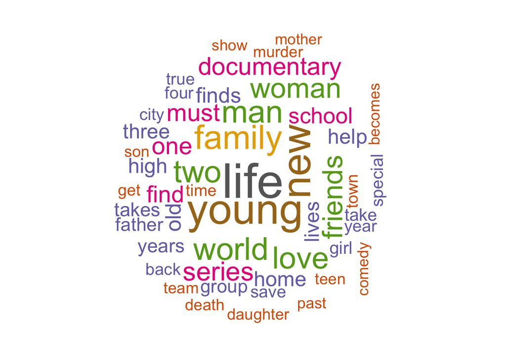

```r
library(wordcloud)
pal <- brewer.pal(8,"Dark2")

df %>%
  filter(century=='21') %>%
  unnest_tokens(input = description, output = word) %>%
  anti_join(get_stopwords()) %>%
  count(century, word, sort = TRUE) %>%
  with(wordcloud(word, n, random.order = FALSE, max.words = 50, colors=pal))
```

**4. Sentiment Analysis**

1. Is movies/TV Shows in the 21st century tends to be more positive than those in 20th century? Use the sentiment analysis by `Bing` lexicons to address the question.

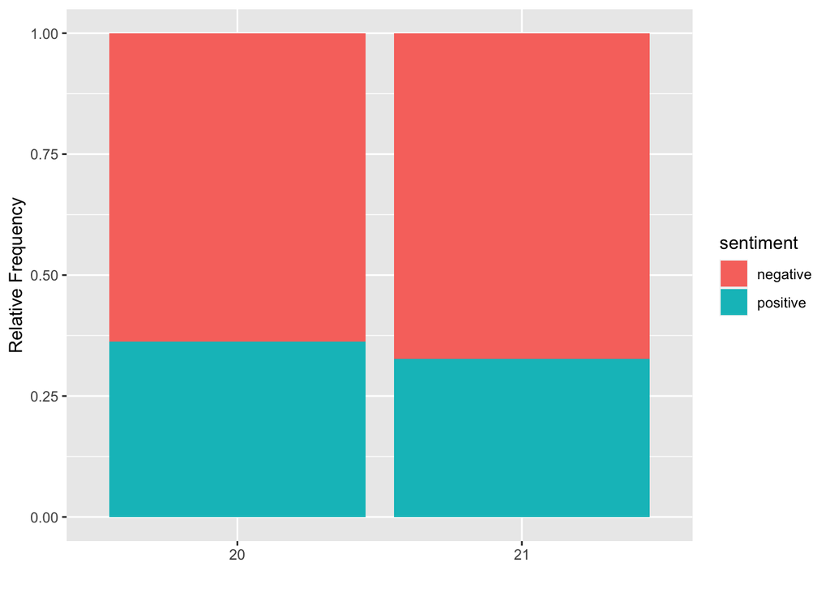

```r
df %>%
    unnest_tokens(input = description, output = word) %>%
    anti_join(get_stopwords()) %>%
    count(century, word, sort = TRUE) %>%
    group_by(century) %>%
    inner_join(get_sentiments("bing")) %>%
    filter(!is.na(sentiment)) %>%
    count(sentiment, sort = TRUE) %>%
    group_by(century) %>%
    mutate(n = n/sum(n)) %>%
    ggplot(aes(century, n, fill=sentiment))+geom_col(position = 'fill')+
    labs(y='Relative Frequency', x ='')
```

Movies/TV Shows tend to be more negative during the 21st century than they were during the 20th century.

2. Do sentiment analysis using `nrc` and `afinn` lexicons. Give your comments on the results.

‘NRC’

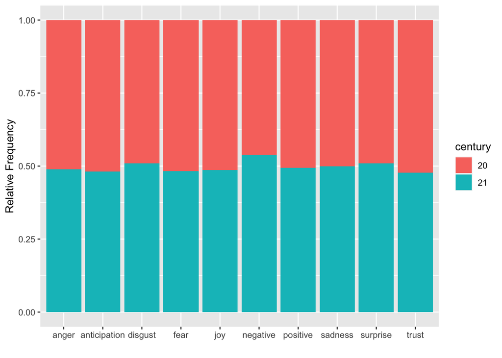

```r
df %>%
    unnest_tokens(input = description, output = word) %>%
    anti_join(get_stopwords()) %>%
    count(century, word, sort = TRUE) %>%
    group_by(century) %>%
    inner_join(get_sentiments("nrc")) %>%
    filter(!is.na(sentiment)) %>%
    count(sentiment, sort = TRUE) %>%
    group_by(century) %>%
    mutate(n = n/sum(n)) %>%
    ggplot(aes(sentiment, n, fill=century))+geom_col(position = 'fill')+
    labs(y='Relative Frequency', x ='')
```

‘Affin’

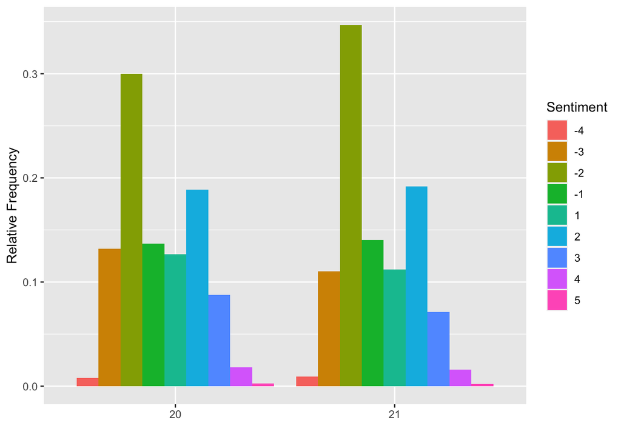

```r
df %>%
    unnest_tokens(input = description, output = word) %>%
    anti_join(get_stopwords()) %>%
    count(century, word, sort = TRUE) %>%
    group_by(century) %>%
    inner_join(get_sentiments("afinn")) %>%
    mutate(sentiment = value) %>%
    filter(!is.na(sentiment)) %>%
    count(sentiment, sort = TRUE) %>%
    group_by(century) %>%
    mutate(n = n/sum(n)) %>%
    ggplot(aes(century, n, fill=factor(sentiment)))+geom_col(position = 'dodge')+
    labs(y='Relative Frequency', fill = 'Sentiment', x = '')
```

**5. Modeling**

1. Use the description to predict if a movie/TV show is in 20th or 21st century. Give the accuracy and plot the confusion matrix table.

```r
library(caret)
library(themis)
library(textrecipes)

# Select data and set target
df <- df %>%
  mutate(target = century) %>%
  select(target, description)

# Convert text data to numeric variables
a <- recipe(target~description,
       data = df) %>%
  step_tokenize(description) %>%
  step_tokenfilter(description, max_tokens = 50) %>%
  step_tfidf(description) %>%
  step_normalize(all_numeric_predictors()) %>%
  step_smote(target) %>%
  prep()
df <- juice(a)

# Using Caret for modeling
set.seed(2021)
splitIndex <- createDataPartition(df$target, p = .1,
                                  list = FALSE)
df_train <- df[ splitIndex,]
df_test <- df[-splitIndex,]

forest_ranger <- train(target~., data=df_train,
                        method = "ranger")

pred <- predict(forest_ranger, df_test)

cm <- confusionMatrix(data = pred, reference = df_test$target)
cm$overall[1]
```

```
##  Accuracy
## 0.9105088
```

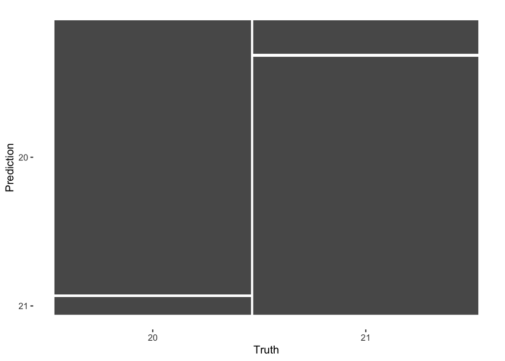

```r
d = data.frame(pred = pred, obs = df_test$target)
library(yardstick)
d %>% conf_mat(pred, obs) %>% autoplot
```

2. Create variable century2 taking three following values. (Hint: You can use the case_when function to do this)

```
- `21` if released_year is greater or equal to 2000
- `second_half_20`if released_year is greater than or equal to 1950 and less than 2000
- `first_half_20` otherwise
```

```r
df <- read_csv('netflix_titles (11).csv')
df$century2 <- case_when(df$release_year>=2000 ~ '21',
                         df$release_year<=1950 ~ 'first_half_20',
                         TRUE ~ 'second_half_20')
```

Predict century2 using the descriptions. Give the accuracy and plot the confusion matrix table. (Notice that the codes for 8 should still work for this question)

```r
library(caret)
library(themis)
library(textrecipes)

# Select data and set target
df <- df %>%
  mutate(target = century2) %>%
  select(target, description)

# Convert text data to numeric variables
a <- recipe(target~description,
       data = df) %>%
  step_tokenize(description) %>%
  step_tokenfilter(description, max_tokens = 50) %>%
  step_tfidf(description) %>%
  step_normalize(all_numeric_predictors()) %>%
  step_smote(target) %>%
  prep()
df <- juice(a)

# Using Caret for modeling
set.seed(2021)
splitIndex <- createDataPartition(df$target, p = .1,
                                  list = FALSE)
df_train <- df[ splitIndex,]
df_test <- df[-splitIndex,]

forest_ranger <- train(target~., data=df_train,
                        method = "ranger")
pred <- predict(forest_ranger, df_test)

cm <- confusionMatrix(data = pred, reference = df_test$target)
cm$overall[1]
```

```
##  Accuracy
## 0.9209065
```

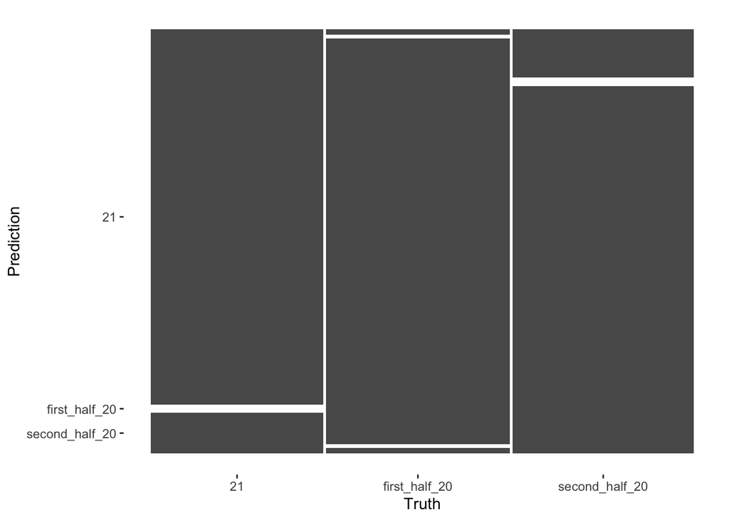

```r
d = data.frame(pred = pred, obs = df_test$target)
library(yardstick)
d %>% conf_mat(pred, obs) %>% autoplot
```

**6.** Create another categorical variable from the data and do the following

```
- Plot side-by-side word frequency by different categories of the newly created variable
```

```r
df <- read_csv('netflix_titles (11).csv')
```

```r
df$kids = case_when(df$rating=='PG-13' ~ 'Kids', TRUE ~ 'Adults')
```

```
- Plot word clouds on different categories of the newly created variable

- Do sentiment analysis to compare different categories of the newly created variable
```

[figure not shown]

[output not shown]

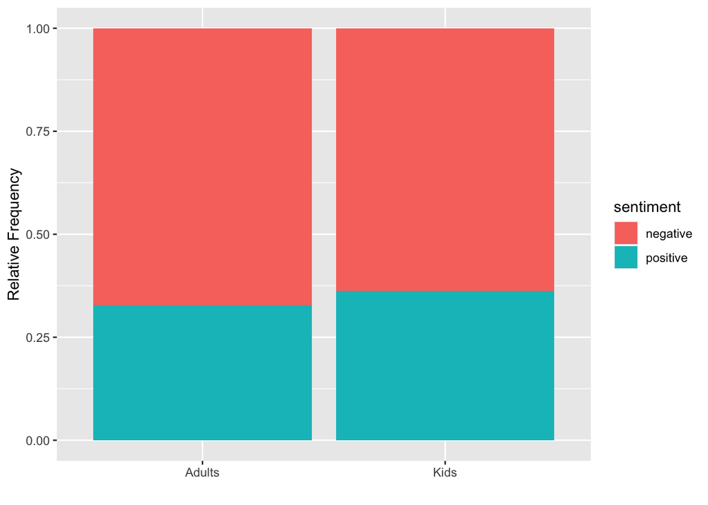

[output not shown]

[output not shown]

[output not shown]

[figure not shown]

```r
library(wordcloud)
pal <- brewer.pal(8,"Dark2")

df %>%
  filter(kids=='Kids') %>%
  unnest_tokens(input = description, output = word) %>%
  anti_join(get_stopwords()) %>%
  count(kids, word, sort = TRUE) %>%
  with(wordcloud(word, n, random.order = FALSE, max.words = 50, colors=pal))
```

[output not shown]

- Plot word clouds on different categories of the `rating` variable

- Do sentiment analysis to compare different categories of the `rating` variable